# Week5-3_DETECTING VANDALISM ON WIKIPEDIA

Kyu Cho

July 4, 2015

# Introduction

Wikipedia is a free online encyclopedia that anyone can edit and contribute to. It is available in many languages and is growing all the time. On the English language version of Wikipedia:

There are currently 4.7 million pages.  
There have been a total over 760 million edits (also called revisions) over its lifetime.  
There are approximately 130,000 edits per day.  
One of the consequences of being editable by anyone is that some people vandalize pages. This can take the form of removing content, adding promotional or inappropriate content, or more subtle shifts that change the meaning of the article. With this many articles and edits per day it is difficult for humans to detect all instances of vandalism and revert (undo) them. As a result, Wikipedia uses bots - computer programs that automatically revert edits that look like vandalism. In this assignment we will attempt to develop a vandalism detector that uses machine learning to distinguish between a valid edit and vandalism.

The data for this problem is based on the revision history of the page Language. Wikipedia provides a history for each page that consists of the state of the page at each revision. Rather than manually considering each revision, a script was run that checked whether edits stayed or were reverted. If a change was eventually reverted then that revision is marked as vandalism. This may result in some misclassifications, but the script performs well enough for our needs.

# Variables

As a result of this preprocessing, some common processing tasks have already been done, including lower-casing and punctuation removal. The columns in the dataset are:

- Vandal = 1 if this edit was vandalism, 0 if not.
- Minor = 1 if the user marked this edit as a “minor edit”, 0 if not.
- Loggedin = 1 if the user made this edit while using a Wikipedia account, 0 if they did not.
- Added = The unique words added.
- Removed = The unique words removed. Notice the repeated use of unique. The data we have available is not the traditional bag of words - rather it is the set of words that were removed or added. For example, if a word was removed multiple times in a revision it will only appear one time in the “Removed” column.

```r
library(caTools)
library(tm)
library(SnowballC)
library(rpart)
library(rpart.plot)
library(randomForest)
library(ROCR)

setwd("D:/Google Drive/College/4-The Analytics Edge/data5")

# stringsAsFactors false for working on a text analytics to read in properly.
wiki = read.csv("wiki.csv", stringsAsFactors = FALSE)
summary(wiki)
```

```
##       X.1             X            Vandal           Minor
##  Min.   :   1   Min.   :   1   Min.   :0.0000   Min.   :0.0000
##  1st Qu.:1001   1st Qu.:1184   1st Qu.:0.0000   1st Qu.:0.0000
##  Median :2016   Median :2318   Median :0.0000   Median :0.0000
##  Mean   :2040   Mean   :2322   Mean   :0.4683   Mean   :0.2853
##  3rd Qu.:3069   3rd Qu.:3467   3rd Qu.:1.0000   3rd Qu.:1.0000
##  Max.   :4135   Max.   :4639   Max.   :1.0000   Max.   :1.0000
##     Loggedin         Added             Removed
##  Min.   :0.0000   Length:3876        Length:3876
##  1st Qu.:0.0000   Class :character   Class :character
##  Median :1.0000   Mode  :character   Mode  :character
##  Mean   :0.6659
##  3rd Qu.:1.0000
##  Max.   :1.0000
```

```r
str(wiki)
```

```
## 'data.frame':    3876 obs. of  7 variables:
##  $ X.1     : int  1 2 3 4 5 6 7 8 9 10 ...
##  $ X       : int  1 2 3 4 5 6 7 8 9 10 ...
##  $ Vandal  : int  0 0 0 0 0 0 0 0 0 0 ...
##  $ Minor   : int  1 1 0 1 1 0 0 0 1 0 ...
##  $ Loggedin: int  1 1 1 0 1 1 1 1 1 0 ...
##  $ Added   : chr  "  represent psycholinguisticspsycholinguistics orthographyorthography help text all actions through human ethnologue relationsh"| __truncated__ " website external links" " " " afghanistan used iran mostly that farsiis is countries some xmlspacepreservepersian parts tajikestan r…
##  $ Removed : chr  " " " talklanguagetalk" " regarded as technologytechnologies human first" "  represent psycholinguisticspsycholinguistics orthographyorthography help all actions through ethnologue relationships linguis"| __truncated__ ...
```

```r
# Convert one of the element as a factor element
wiki$Vandal = as.factor(wiki$Vandal)
```

## Cleaning the data

```r
# Create Corpus
corpusAdded = Corpus(VectorSource(wiki$Added))
corpusRemoved = Corpus(VectorSource(wiki$Removed))

corpusAdded = tm_map(corpusAdded, removeWords, stopwords("english"))
corpusRemoved = tm_map(corpusRemoved, removeWords, stopwords("english"))

corpusAdded = tm_map(corpusAdded, stemDocument)
corpusRemoved = tm_map(corpusRemoved, stemDocument)

# Look at the first document
corpusAdded[[1]]
```

```
## <<PlainTextDocument>>
## Metadata:  7
## Content:  chars: 865
```

```r
strwrap(corpusAdded[[1]])
```

```
##  [1] "repres psycholinguisticspsycholinguist orthographyorthographi help"
##  [2] "text action human ethnologu relationship linguist regard write"
##  [3] "languag list xmlspacepreservelanguag metavers formal term philolog"
##  [4] "common includ phonologyphonolog often ten list human affili see"
##  [5] "comput speechpathologyspeech way dialect pleas artifici written"
##  [6] "bodi quit hypothesi found alon refer languag profan studi program"
##  [7] "prioriti rosenfeld technologytechnolog make first among use"
##  [8] "languagephilosophi one sound use area creat phrase mark genet"
##  [9] "basic famili complet sapirwhorfhypothesissapirwhorf"
## [10] "talklanguagetalk popul anim scienc vocal can concept call topic"
## [11] "locat number patholog differ develop 4000 thing idea group complex"
## [12] "anim mathemat fair literatur httpwwwzompistcom philosophi import"
## [13] "meaning historicallinguisticsorphilologyhistor semanticssemant"
## [14] "pattern oral"
```

## Removing Sparse Terms

```r
# Create matrix
dtmAdded = DocumentTermMatrix(corpusAdded)
dtmRemoved = DocumentTermMatrix(corpusRemoved)

# Minimize the data
sparseAdded = removeSparseTerms(dtmAdded, 0.997)
sparseRemoved = removeSparseTerms(dtmRemoved, 0.997)

# Conerting into data frame
wordsAdded = as.data.frame(as.matrix(sparseAdded))
wordsRemoved = as.data.frame(as.matrix(sparseRemoved))

# Add R to wordsRemoved variables, A to wordsAdded variable name.
colnames(wordsAdded) = paste("A", colnames(wordsAdded))
colnames(wordsRemoved) = paste("R", colnames(wordsRemoved))

#Combine the two dataframes
wikiWords = cbind(wordsAdded, wordsRemoved)

# Add the Vandal variable
wikiWords$Vandal = wiki$Vandal
```

# Build model

## Split the data set

```r
set.seed(123)
split = sample.split(wikiWords, SplitRatio=0.7)
train = subset(wikiWords, split==TRUE)
test = subset(wikiWords, split==FALSE)
```

## Base model

```r
# Accuracy of the baseline that always "not vandalism"
table = table(test$Vandal)
accuracy = table[1]/sum(table)
accuracy
```

```
##         0
## 0.5343643
```

## CART model

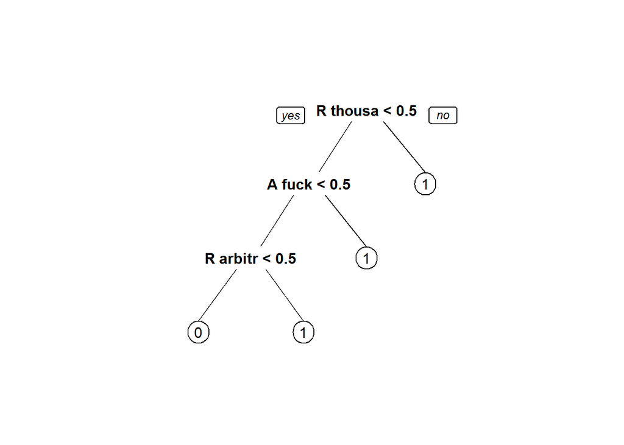

```r
model = rpart(Vandal~., data=train, method="class")
prp(model)
```

```r
# Accuracy
pred = predict(model, newdata=test)
pred = pred[,2]
table2 = table(test$Vandal, pred >= 0.5)
accuracy2 = (table2[1,1]+table2[2,2])/sum(table2)
accuracy2
```

```
## [1] 0.5463918
```

## Validation

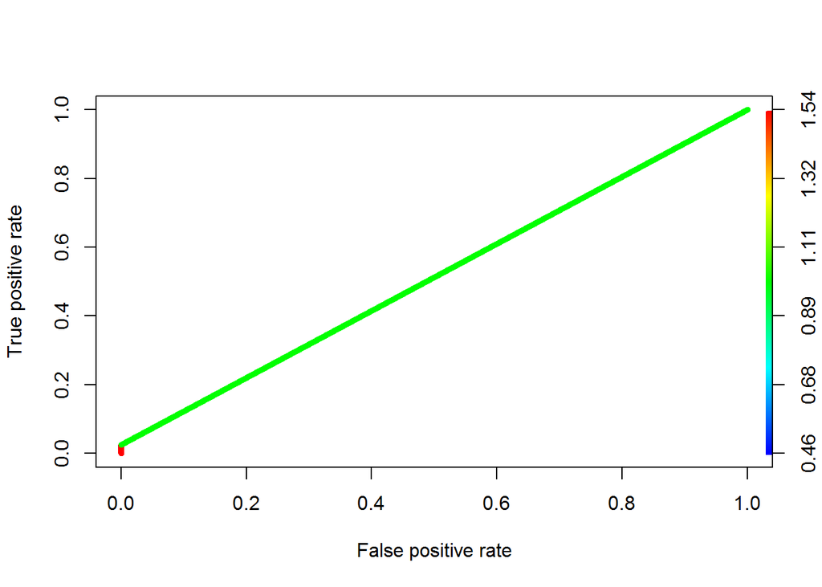

```r
# ROC curve
predROCR = prediction(pred, test$Vandal)
perfROCR = performance(predROCR, "tpr", "fpr")
plot(perfROCR, colorize=TRUE, lwd = 5)
```

```r
# Compute AUC
performance(predROCR, "auc")@y.values
```

```
## [[1]]
## [1] 0.5129151
```

There is no reason to think there was anything wrong with the split. CART did not overfit, which you can check by computing the accuracy of the model on the training set. Over-sparsification is plausible but unlikely, since we selected a very high sparsity parameter. The only conclusion left is simply that bag of words didn’t work very well in this case.

# PROBLEM-SPECIFIC KNOWLEDGE

We weren’t able to improve on the baseline using the raw textual information. More specifically, the words themselves were not useful. There are other options though, and in this section we will try two techniques - identifying a key class of words, and counting words.

The key class of words we will use are website addresses. “Website addresses” (also known as URLs - Uniform Resource Locators) are comprised of two main parts. An example would be “http://www.google.com”. The first part is the protocol, which is usually “http” (HyperText Transfer Protocol). The second part is the address of the site, e.g. “www.google.com”. We have stripped all punctuation so links to websites appear in the data as one word, e.g. “httpwwwgooglecom”. We hypothesize that given that a lot of vandalism seems to be adding links to promotional or irrelevant websites, the presence of a web address is a sign of vandalism.

We can search for the presence of a web address in the words added by searching for “http” in the Added column.

```r
#Create a copy of the dataframe from the previous question:
wikiWords2 = wikiWords

# Make a new column in wikiWords2 that is 1 if "http" was in Added
# The grepl function returns TRUE if a string is found in another string.
wikiWords2$HTTP = ifelse(grepl("http",wiki$Added,fixed=TRUE), 1, 0)
```

## Split data

```r
# Training and test data sets
wikiTrain2 = subset(wikiWords2, split==TRUE)
wikiTest2 = subset(wikiWords2, split==FALSE)
```

## CART model

```r
# Build a CART model
wikiCART2 = rpart(Vandal ~ ., data=wikiTrain2, method="class")

# Accuracy
pred2 = predict(wikiCART2, newdata=wikiTest2, type="class")
table3 = table(wikiTest2$Vandal, pred2)
(table3[1,1]+table3[2,2])/sum(table3)
```

```
## [1] 0.5867698
```

Another possibility is that the number of words added and removed is predictive, perhaps more so than the actual words themselves.

```r
# Sum the rows of dtmAdded and dtmRemoved and add them as new variables in data frame wikiWords2
wikiWords2$NumWordsAdded = rowSums(as.matrix(dtmAdded))
wikiWords2$NumWordsRemoved = rowSums(as.matrix(dtmRemoved))

# Average number of words added
mean(wikiWords2$NumWordsAdded)
```

```
## [1] 4.050052
```

```r
# Build a CART model
wikiTrain3 = subset(wikiWords2, split==TRUE)
wikiTest3 = subset(wikiWords2, split==FALSE)
wikiCART3 = rpart(Vandal ~ ., data=wikiTrain3, method="class")
pred3 = predict(wikiCART3, newdata=wikiTest3, type="class")
table4 = table(wikiTest3$Vandal, pred3)
(table4[1,1]+table4[2,2])/sum(table4)
```

```
## [1] 0.6572165
```

# USING NON-TEXTUAL DATA

```r
# Make a copy of wikiWords2, and call it wikiWords3
wikiWords3 = wikiWords2
wikiWords3$Minor = wiki$Minor
wikiWords3$Loggedin = wiki$Loggedin

wikiTrain4 = subset(wikiWords3, split==TRUE)
wikiTest4 = subset(wikiWords3, split==FALSE)
wikiCART4 = rpart(Vandal ~ ., data=wikiTrain4, method="class")
pred4 = predict(wikiCART4, newdata=wikiTest4, type="class")
table5 = table(wikiTest4$Vandal, pred4)
(table5[1,1]+table5[2,2])/sum(table5)
```

```
## [1] 0.7139175
```

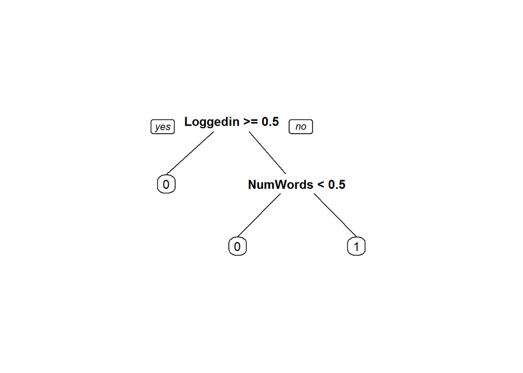

```r
prp(wikiCART4)
```